# Project3-DataCleaning

### Data Cleaning and EDA

##### Objective:

1. Discover and remedy missing values, outliers and anomalies present in dataset.
2. Discern demarcations between nondiabetic and diabetic populations.
3. Determine that both nondiabetic and diabetic groups are statistically signficantly different.
4. Develop mutlivariate relationship visualizations.
5. Deliver final cleaned dataset for SVM analysis.

##### Libraries and Settings

```python
import numpy as np
import pandas as pd
import matplotlib as mpl
import matplotlib.pyplot as plt
import seaborn as sns
from pandas.api.types import CategoricalDtype
from scipy import stats
sns.set(style="white")
```

##### Data Representation

```python
data = pd.read_csv('diabetes_explore2.csv')
```

```python
data.head(7)
```

|  | preg | plas | pres | skin | insu | mass | pedi | age | class | age_level |
| --- | --- | --- | --- | --- | --- | --- | --- | --- | --- | --- |
| 0 | 6 | 148 | 72 | 35 | 0 | 33.6 | 0.627 | 50 | 1 | 50s |
| 1 | 1 | 85 | 66 | 29 | 0 | 26.6 | 0.351 | 31 | 0 | 30s |
| 2 | 8 | 183 | 64 | 0 | 0 | 23.3 | 0.672 | 32 | 1 | 30s |
| 3 | 1 | 89 | 66 | 23 | 94 | 28.1 | 0.167 | 21 | 0 | 20s |
| 4 | 0 | 137 | 40 | 35 | 168 | 43.1 | 2.288 | 33 | 1 | 30s |
| 5 | 5 | 116 | 74 | 0 | 0 | 25.6 | 0.201 | 30 | 0 | 30s |
| 6 | 3 | 78 | 50 | 32 | 88 | 31.0 | 0.248 | 26 | 1 | 20s |

```python
data.info()
```

```
<class 'pandas.core.frame.DataFrame'>
RangeIndex: 768 entries, 0 to 767
Data columns (total 10 columns):
preg         768 non-null int64
plas         768 non-null int64
pres         768 non-null int64
skin         768 non-null int64
insu         768 non-null int64
mass         768 non-null float64
pedi         768 non-null float64
age          768 non-null int64
class        768 non-null int64
age_level    768 non-null object
dtypes: float64(2), int64(7), object(1)
memory usage: 60.1+ KB
```

```python
print(data.shape)
```

```
(768, 10)
```

10 varying column variables of mixed datatypes (int64 and float64) present in the 768 patient pool

```python
data.isna().sum()
```

```
preg         0
plas         0
pres         0
skin         0
insu         0
mass         0
pedi         0
age          0
class        0
age_level    0
dtype: int64
```

No NA values exist in data

```python
data.var()
```

```
preg        11.354056
plas      1022.248314
pres       374.647271
skin       254.473245
insu     13281.180078
mass        62.159984
pedi         0.109779
age        138.303046
class        0.227483
dtype: float64
```

##### Min Max Data Cleaning

```python
data.describe()
```

|  | preg | plas | pres | skin | insu | mass | pedi | age | class |
| --- | --- | --- | --- | --- | --- | --- | --- | --- | --- |
| count | 768.000000 | 768.000000 | 768.000000 | 768.000000 | 768.000000 | 768.000000 | 768.000000 | 768.000000 | 768.000000 |
| mean | 3.845052 | 120.894531 | 69.105469 | 20.536458 | 79.799479 | 31.992578 | 0.471876 | 33.240885 | 0.348958 |
| std | 3.369578 | 31.972618 | 19.355807 | 15.952218 | 115.244002 | 7.884160 | 0.331329 | 11.760232 | 0.476951 |
| min | 0.000000 | 0.000000 | 0.000000 | 0.000000 | 0.000000 | 0.000000 | 0.078000 | 21.000000 | 0.000000 |
| 25% | 1.000000 | 99.000000 | 62.000000 | 0.000000 | 0.000000 | 27.300000 | 0.243750 | 24.000000 | 0.000000 |
| 50% | 3.000000 | 117.000000 | 72.000000 | 23.000000 | 30.500000 | 32.000000 | 0.372500 | 29.000000 | 0.000000 |
| 75% | 6.000000 | 140.250000 | 80.000000 | 32.000000 | 127.250000 | 36.600000 | 0.626250 | 41.000000 | 1.000000 |
| max | 17.000000 | 199.000000 | 122.000000 | 99.000000 | 846.000000 | 67.100000 | 2.420000 | 81.000000 | 1.000000 |

Maximum and Minimum values flagged for potential outliers:

Plasma: biologically values for plasma cannot be 0, higher values (such as 199) should be addressed as outliers.

Skin: biologically values for skin mM thickness cannot be 0, higher values may be connected with a T2 diabetic cormorbidity with obesity.

Insulin: biologically values for insulin cannot be 0, moreover higher values (such as 846) should be adddresed as outliers.

Mass: biologically values for mass cannot be 0.

All other column variables appear to be clean.

##### Data Cleaning Treatment

```python
clean = data.copy(deep=True)
```

```python
clean['insu'].replace(0, np.NaN,inplace=True)
clean['insu'].replace(846, np.NaN,inplace=True)
clean['pres'].replace(0, np.NaN,inplace=True)
clean['skin'].replace(0, np.NaN,inplace=True)
clean['mass'].replace(0, np.NaN,inplace=True)
clean['plas'].replace(0, np.NaN,inplace=True)
clean['plas'].replace(199, np.NaN,inplace=True)
```

```python
clean.isna().sum()
```

```
preg           0
plas           6
pres          35
skin         227
insu         375
mass          11
pedi           0
age            0
class          0
age_level      0
dtype: int64
```

```python
clean.loc[data['class'] == 0].count()
```

```
preg         500
plas         497
pres         481
skin         361
insu         264
mass         491
pedi         500
age          500
class        500
age_level    500
dtype: int64
```

Data lost in column variables: plas, pres, skin, insu, and mass

```python
clean.loc[data['class'] == 1].count()
```

```
preg         268
plas         265
pres         252
skin         180
insu         129
mass         266
pedi         268
age          268
class        268
age_level    268
dtype: int64
```

Data lost in column variables: plas, pres, skin, insu, and mass

##### Disease Class Description

```python
DiseaseStatus = clean.groupby(['class'])
DiseaseStatus.describe()
```

| class | preg count | preg mean | preg std | preg min | preg 25% | preg 50% | preg 75% | preg max | plas count | plas mean | ... | pedi 75% | pedi max | age count | age mean | age std | age min | age 25% | age 50% | age 75% | age max |
| --- | --- | --- | --- | --- | --- | --- | --- | --- | --- | --- | --- | --- | --- | --- | --- | --- | --- | --- | --- | --- | --- |
| 0 | 500.0 | 3.298000 | 3.017185 | 0.0 | 1.00 | 2.0 | 5.0 | 13.0 | 497.0 | 110.643863 | ... | 0.56175 | 2.329 | 500.0 | 31.190000 | 11.667655 | 21.0 | 23.0 | 27.0 | 37.0 | 81.0 |
| 1 | 268.0 | 4.865672 | 3.741239 | 0.0 | 1.75 | 4.0 | 8.0 | 17.0 | 265.0 | 142.105660 | ... | 0.72800 | 2.420 | 268.0 | 37.067164 | 10.968254 | 21.0 | 28.0 | 36.0 | 44.0 | 70.0 |

2 rows × 64 columns

```python
DiseaseStatus.mean()
```

| class | preg | plas | pres | skin | insu | mass | pedi | age |
| --- | --- | --- | --- | --- | --- | --- | --- | --- |
| 0 | 3.298000 | 110.643863 | 70.877339 | 27.235457 | 130.287879 | 30.859674 | 0.429734 | 31.190000 |
| 1 | 4.865672 | 142.105660 | 75.321429 | 33.000000 | 201.891473 | 35.406767 | 0.550500 | 37.067164 |

268 diabetic patients present and 500 nondiabietic patients in sample.

**Mean value comparison between classes**

*excluding missing values:*

Amount of pregnancies is ~1 lower in nondiabetics (non diabetic: 3.298 pregancies, diabetic: 4.865672 pregnancies),

Plasma values are ~32 units lower in nondiabetics (non diabetic: 110.643863 glucose concentration, diabetic: 142.105660 glucose concentration),

Blood pressure is ~5 mm Hg lower in nondiabetics than diabetics patients (non diabetic: 70.877339 mm Hg, diabetic: 75.321429 mm Hg)

Skin thickness is ~ 6 mm lower in nondiabetics than diabetics patients (non diabetic: 27.235457 mm, diabetic: 33.000000 mm)

Insulin values are ~71 mu U/mL lower in nondiabetics than diabetic patients (non diabetic: 130.287879 mu U/mL , diabetic: 201.891473 mu U/mL)

Mass values are ~5 bmi units lower in nondiabetics than diabeticc patients (non diabetic: 30.859674 (weight in kg/(height in m)^2, diabetic: 35.406767 (weight in kg/(height in m)^2)

Pedigree values are ~0.13 units lower in nondiabetics than diabeticc patients (non diabetic: 0.429734, diabetic: 0.550500)

#### Age Level Description

```python
Ages = data.groupby(['age_level'])
Ages.describe()
```

| age_level | preg count | preg mean | preg std | preg min | preg 25% | preg 50% | preg 75% | preg max | plas count | plas mean | ... | age 75% | age max | class count | class mean | class std | class min | class 25% | class 50% | class 75% | class max |
| --- | --- | --- | --- | --- | --- | --- | --- | --- | --- | --- | --- | --- | --- | --- | --- | --- | --- | --- | --- | --- | --- |
| 20s | 396.0 | 1.921717 | 1.733200 | 0.0 | 1.00 | 2.0 | 3.0 | 10.0 | 396.0 | 113.744949 | ... | 26.0 | 29.0 | 396.0 | 0.212121 | 0.409327 | 0.0 | 0.0 | 0.0 | 0.0 | 1.0 |
| 30s | 165.0 | 4.987879 | 3.139030 | 0.0 | 3.00 | 5.0 | 7.0 | 14.0 | 165.0 | 125.309091 | ... | 37.0 | 39.0 | 165.0 | 0.460606 | 0.499963 | 0.0 | 0.0 | 0.0 | 1.0 | 1.0 |
| 40s | 118.0 | 7.050847 | 3.720692 | 0.0 | 5.00 | 7.0 | 9.0 | 17.0 | 118.0 | 124.644068 | ... | 45.0 | 49.0 | 118.0 | 0.550847 | 0.499529 | 0.0 | 0.0 | 1.0 | 1.0 | 1.0 |
| 50s | 57.0 | 6.596491 | 3.411429 | 0.0 | 5.00 | 7.0 | 9.0 | 13.0 | 57.0 | 140.280702 | ... | 57.0 | 59.0 | 57.0 | 0.596491 | 0.494962 | 0.0 | 0.0 | 1.0 | 1.0 | 1.0 |
| 60+ | 32.0 | 5.031250 | 2.923590 | 0.0 | 3.75 | 5.0 | 7.0 | 12.0 | 32.0 | 138.250000 | ... | 67.0 | 81.0 | 32.0 | 0.281250 | 0.456803 | 0.0 | 0.0 | 0.0 | 1.0 | 1.0 |

5 rows × 72 columns

```python
Ages.mean()
```

| age_level | preg | plas | pres | skin | insu | mass | pedi | age | class |
| --- | --- | --- | --- | --- | --- | --- | --- | --- | --- |
| 20s | 1.921717 | 113.744949 | 65.348485 | 21.949495 | 84.393939 | 31.390404 | 0.451048 | 24.313131 | 0.212121 |
| 30s | 4.987879 | 125.309091 | 69.666667 | 20.042424 | 77.812121 | 32.472121 | 0.528067 | 34.109091 | 0.460606 |
| 40s | 7.050847 | 124.644068 | 73.940678 | 20.152542 | 63.898305 | 34.617797 | 0.442975 | 43.466102 | 0.550847 |
| 50s | 6.596491 | 140.280702 | 79.807018 | 16.912281 | 109.403509 | 31.338596 | 0.528930 | 53.842105 | 0.596491 |
| 60+ | 5.031250 | 138.250000 | 75.812500 | 13.468750 | 39.093750 | 28.456250 | 0.444844 | 64.843750 | 0.281250 |

**Mean value comparison between classes**

*excluding missing values:*

Amount of pregnancies: Older woman have more children as time passes. Highest amount of pregnancies occurs in 40s age group('40s', 7).

Blood pressure: As age increases, blood presure mm Hg values increase throughout age groups 20s - 50s, and drop 4 mm Hg in 60+ (('20s', 65.34), ('50s', 79.80), ('60+', 75.81)).

Insulin: Highest insulin concentration values occurs in the age group 50s, indicating higher liklihood of diabetes ('50s', 109.40)

Mass: Highest bmi values occus in the 40s age group, suggesting obesity comorbidity with diabetes ('40s', 34.61)

Pedigree: Highest occurence of diabetic pedigree patients occur in 50s and 30s age level (('30s', 0.5280), ('50s', 0.5289))

Disease Status: Highest proportion of diabetic class patients exist in the 40s and 50s age groups (('40s', 0.550),('50s', 0.596))

##### Preganancy

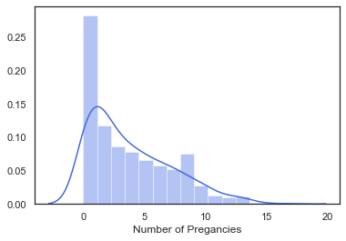

```python
sns.distplot(clean['preg'], bins = 15, color ="royalblue", axlabel ='Number of Pregancies')
```

##### Plasma

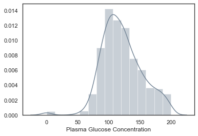

```python
sns.distplot(data['plas'], bins = 15, color ="lightslategrey", axlabel ='Plasma Glucose Concentration')
```

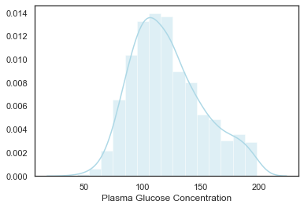

```python
sns.distplot(clean['plas'], bins = 15, color ="lightblue", axlabel ='Plasma Glucose Concentration')
```

##### Blood Pressure

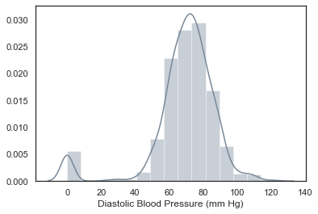

```python
sns.distplot(data['pres'], bins = 15, color ="lightslategrey", axlabel ='Diastolic Blood Pressure (mm Hg)')
```

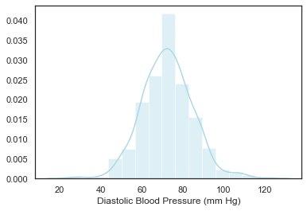

```python
sns.distplot(clean['pres'], bins = 15, color ="lightblue", axlabel ='Diastolic Blood Pressure (mm Hg)')
```

##### Skin Thickness

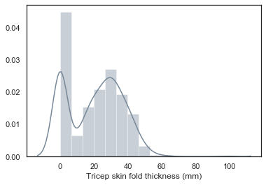

```python
sns.distplot(data['skin'], bins = 15, color ="lightslategrey", axlabel ='Tricep skin fold thickness (mm)')
```

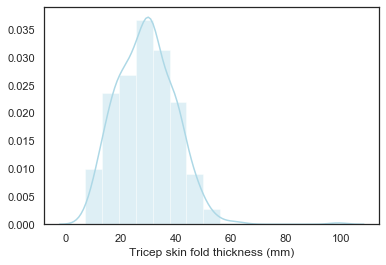

```python
sns.distplot(clean['skin'], bins = 15, color ="lightblue", axlabel ='Tricep skin fold thickness (mm)')
```

##### Insulin

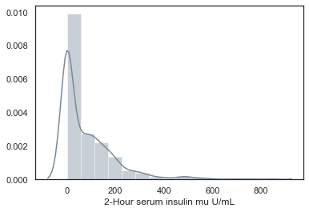

```python
sns.distplot(data['insu'], bins = 15, color ="lightslategrey", axlabel ='2-Hour serum insulin mu U/mL')
```

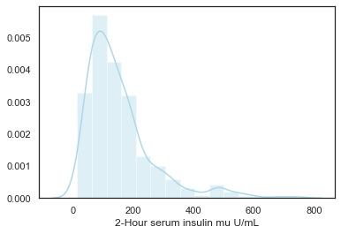

```python
sns.distplot(clean['insu'], bins = 15, color ="lightblue", axlabel ='2-Hour serum insulin mu U/mL')
```

##### BMI

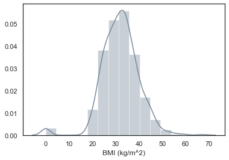

```python
sns.distplot(data['mass'], bins = 15, color ="lightslategrey", axlabel ='BMI (kg/m^2)')
```

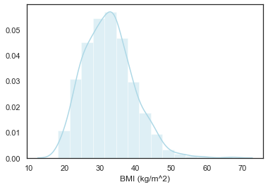

```python
sns.distplot(clean['mass'], bins = 15, color ="lightblue", axlabel ='BMI (kg/m^2)')
```

##### Pedigree

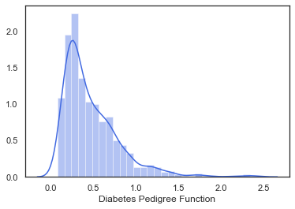

```python
sns.distplot(data['pedi'], color ="royalblue", axlabel ='Diabetes Pedigree Function')
```

##### Age

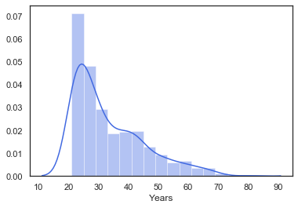

```python
sns.distplot(data['age'], bins = 15, color ="royalblue", axlabel ='Years')
```

##### Class

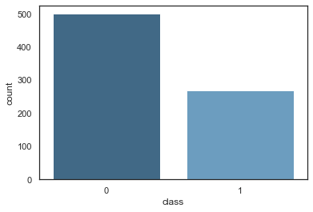

```python
sns.countplot(clean['class'], palette = 'Blues_d')
```

##### Age Level

```python
clean['age_level'] = clean['age_level'].astype('category')
```

```python
clean['age_level'].cat.reorder_categories(['20s', '30s', '40s','50s','60+'])
```

```
0      50s
1      30s
2      30s
3      20s
4      30s
      ...
763    60+
764    20s
765    30s
766    40s
767    20s
Name: age_level, Length: 768, dtype: category
Categories (5, object): [20s, 30s, 40s, 50s, 60+]
```

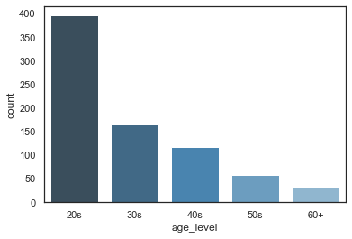

```python
sns.countplot(clean['age_level'], palette = 'Blues_d')
```

##### Correlation

```python
clean.corr(method='spearman')
```

|  | preg | plas | pres | skin | insu | mass | pedi | age | class |
| --- | --- | --- | --- | --- | --- | --- | --- | --- | --- |
| preg | 1.000000 | 0.132127 | 0.194103 | 0.086734 | 0.132331 | 0.000279 | -0.043242 | 0.607216 | 0.198689 |
| plas | 0.132127 | 1.000000 | 0.248897 | 0.226220 | 0.656302 | 0.225164 | 0.087110 | 0.287156 | 0.481798 |
| pres | 0.194103 | 0.248897 | 1.000000 | 0.248017 | 0.135988 | 0.299176 | 0.008511 | 0.370609 | 0.177227 |
| skin | 0.086734 | 0.226220 | 0.248017 | 1.000000 | 0.249116 | 0.685380 | 0.074979 | 0.231132 | 0.265397 |
| insu | 0.132331 | 0.656302 | 0.135988 | 0.249116 | 1.000000 | 0.306992 | 0.131887 | 0.261934 | 0.373418 |
| mass | 0.000279 | 0.225164 | 0.299176 | 0.685380 | 0.306992 | 1.000000 | 0.136138 | 0.121119 | 0.309324 |
| pedi | -0.043242 | 0.087110 | 0.008511 | 0.074979 | 0.131887 | 0.136138 | 1.000000 | 0.042909 | 0.175353 |
| age | 0.607216 | 0.287156 | 0.370609 | 0.231132 | 0.261934 | 0.121119 | 0.042909 | 1.000000 | 0.309040 |
| class | 0.198689 | 0.481798 | 0.177227 | 0.265397 | 0.373418 | 0.309324 | 0.175353 | 0.309040 | 1.000000 |

Interesting correlations to flag for observation or multicollinearity:

mass and skin are highly positively correlated 0.685380

age and preg are highly positively 0.607216

plas and insu are highly positively 0.656302

##### Imputation for Statistical Tests

```python
cleanTest = clean.copy(deep = True)
```

```python
cleanTest['plas'].fillna(clean.plas.median(),inplace=True)
cleanTest['pres'].fillna(clean.plas.median(),inplace=True)
cleanTest['mass'].fillna(clean.plas.median(),inplace=True)
cleanTest['insu'].fillna(clean.plas.median(),inplace=True)
cleanTest['skin'].fillna(clean.plas.median(),inplace=True)
```

```python
nondiabeticPlas= cleanTest[cleanTest['class'] == 0]['plas']
diabeticPlas = cleanTest[cleanTest['class'] == 1]['plas']
stats.ttest_ind(nondiabeticPlas, diabeticPlas)
```

```
Ttest_indResult(statistic=-15.559341153396305, pvalue=1.2205205859331265e-47)
```

```python
nondiabeticPreg= cleanTest[cleanTest['class'] == 0]['preg']
diabeticPreg = cleanTest[cleanTest['class'] == 1]['preg']
stats.ttest_ind(nondiabeticPreg, diabeticPreg)
```

```
Ttest_indResult(statistic=-6.298430550035151, pvalue=5.065127298053476e-10)
```

```python
nondiabeticPlas= cleanTest[cleanTest['class'] == 0]['plas']
diabeticPlas = cleanTest[cleanTest['class'] == 1]['plas']
stats.ttest_ind(nondiabeticPlas, diabeticPlas)
```

```
Ttest_indResult(statistic=-15.559341153396305, pvalue=1.2205205859331265e-47)
```

```python
nondiabeticInsu= cleanTest[cleanTest['class'] == 0]['insu']
diabeticInsu = cleanTest[cleanTest['class'] == 1]['insu']
stats.ttest_ind(nondiabeticInsu, diabeticInsu)
```

```
Ttest_indResult(statistic=-5.465025580661428, pvalue=6.264205216486652e-08)
```

```python
nondiabeticMass= cleanTest[cleanTest['class'] == 0]['mass']
diabeticMass = cleanTest[cleanTest['class'] == 1]['mass']
stats.ttest_ind(nondiabeticMass, diabeticMass)
```

```
Ttest_indResult(statistic=-3.947716669720599, pvalue=8.616365262789469e-05)
```

```python
nondiabeticMass= cleanTest[cleanTest['class'] == 0]['pres']
diabeticMass = cleanTest[cleanTest['class'] == 1]['pres']
stats.ttest_ind(nondiabeticMass, diabeticMass)
```

```
Ttest_indResult(statistic=-4.5398492970363655, pvalue=6.535514740031382e-06)
```

```python
nondiabeticAge= cleanTest[cleanTest['class'] == 0]['age']
diabeticAge = cleanTest[cleanTest['class'] == 1]['age']
stats.ttest_ind(nondiabeticAge, diabeticAge)
```

```
Ttest_indResult(statistic=-6.792688071649956, pvalue=2.2099754606654358e-11)
```

All statistical measures performed indicate that the means of the class groups are distinctly different from one another.

##### Bivariate Relationships

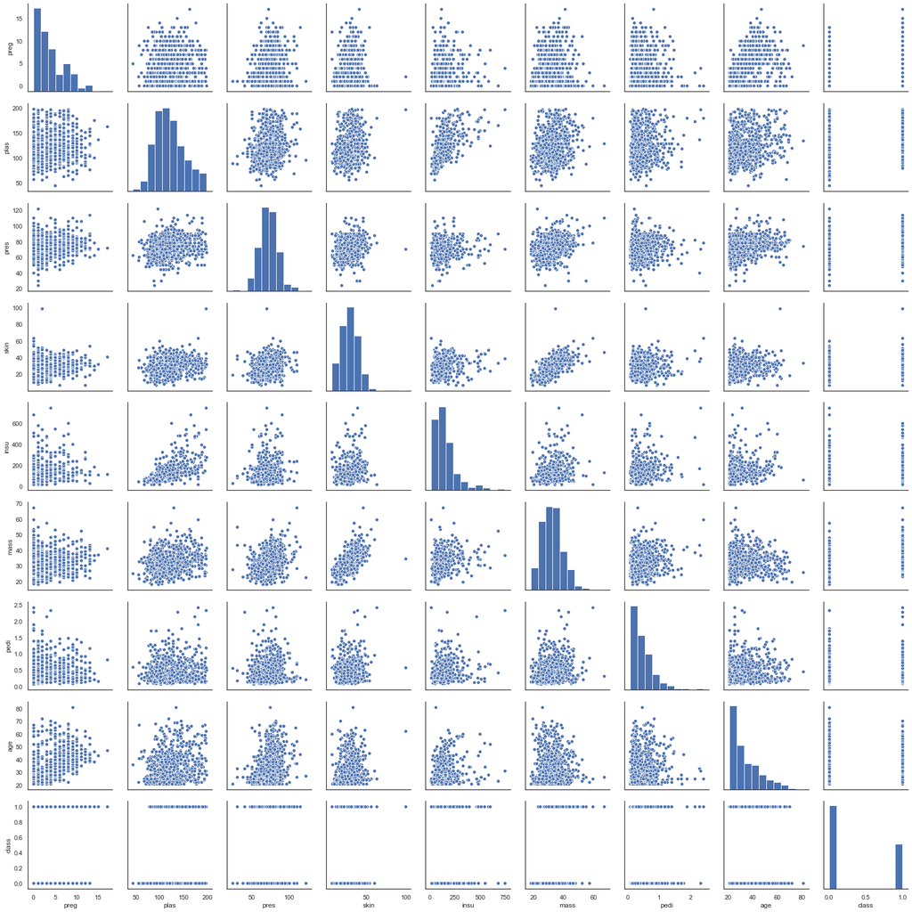

```python
sns.pairplot(clean)
```

##### Plasma concentration and Blood Pressure

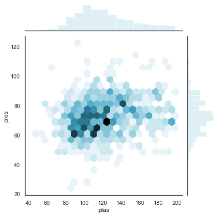

```python
with sns.axes_style("white"): sns.jointplot(clean['plas'], clean['pres'], kind="hex", color="lightblue");
```

Highest occurence of values centralized along 110 plas, 75 mmHg.

##### Age and Blood Pressure

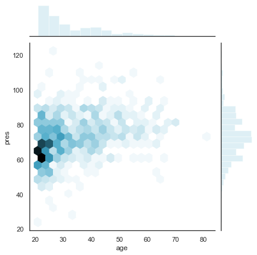

```python
with sns.axes_style("white"): sns.jointplot(clean['age'], clean['pres'], kind="hex", color="lightblue");
```

Highest occurence of patients centralized along 22 years, 60 mm Hg.

Indicates that the sample has a large proportion of younger patients.

##### Age and Mass

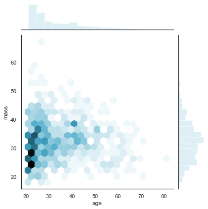

```python
with sns.axes_style("white"): sns.jointplot(clean['age'], clean['mass'], kind="hex", color="lightblue");
```

Highest occurence of patients centralized along age 20 with a bmi of ~25.

##### Insulin and Plasma

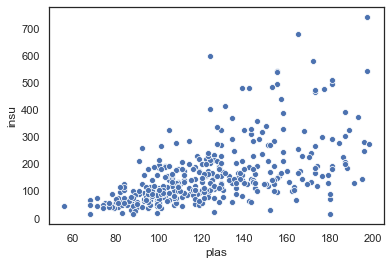

```python
sns.scatterplot(x="plas",y="insu",data=clean,palette='GnBu_d')
```

Highest occurence of values along 80-120 plasma concentration.

Moreover, we can see a characteristic trend of insulin response increasing to circulating plasma.

##### Mass and Skin

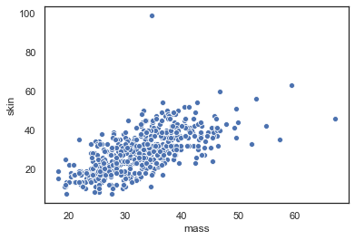

```python
sns.scatterplot(x="mass",y="skin",data=clean,palette='GnBu_d')
```

The highest occurence of patients is between 30 - 40 bmi with a tricep skin fold thickness less than or equal to 40 mm.

##### Age Level and Plasma Varied by Class

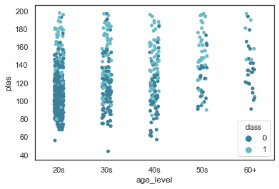

```python
sns.stripplot(x="age_level",y="plas",data=clean,jitter=True,hue='class',palette='GnBu_d')
```

We see the highest occurence of nondiabetic patients in the 20s age group.

##### Plasma and Blood Pressure Varied by Age Level

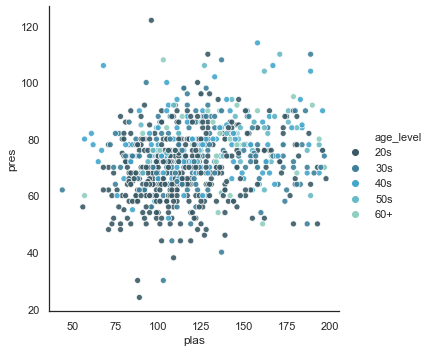

```python
sns.relplot(x="plas",y="pres",data=clean,hue='age_level', alpha = 0.9,palette='GnBu_d')
```

The 20s age_level exhibits a wide distribution across the range of values for plasma. Whereas the older age_groups centralize along higher blood pressure and higher plasma values.

##### Plasma and Blood Pressure Varied by Class

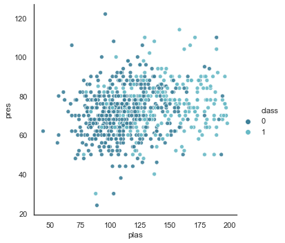

```python
sns.relplot(x="plas",y="pres",data=clean,hue='class', alpha = 0.9,palette='GnBu_d')
```

When varying the sample population by disease classification status:

Diabetics predominantly have plasma concentrations 125 and above, with blood pressure 75 mm Hg whereas nondiabetics typically have lower plasma concentrations and associated blood pressure.

##### Skin Thickness and Blood Pressure Varied by Age Level

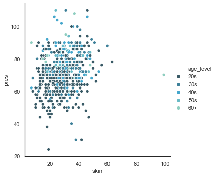

```python
sns.relplot(x="skin",y="pres",data=clean,hue='age_level',palette='GnBu_d')
```

##### Skin Thickness and Blood Pressure Varied By Disease Classification Status

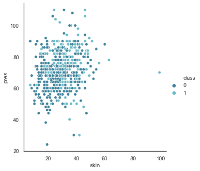

```python
sns.relplot(x="skin",y="pres",data=clean,hue='class',palette='GnBu_d')
```

One may observe that higher skin fold thickness values occur in both diabetic and nondiabetic patients. However the higher frequency of lower skin thickness and blood pressure exists in nondiabetic patients.

##### Age and Skin Fold Thickness Varied By Disease Classification Status

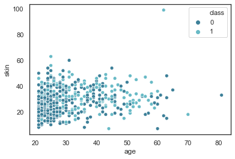

```python
sns.scatterplot(x="age",y="skin",data=clean,hue='class',palette='GnBu_d')
```

We see a higher frequency of diabetics in ages closer 45 and a higher frequency of younger nondiabetic patients.

##### Age Level and Skin Fold Thickness

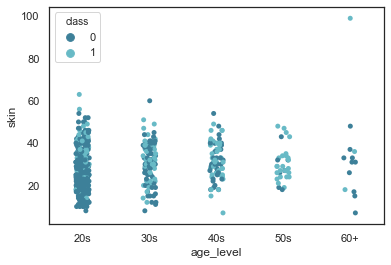

```python
sns.stripplot(x="age_level",y="skin",data=clean,jitter=True,hue='class',palette='GnBu_d')
```

One may observe that there is a frequency of skin thickness along 35 mm skin measurement between both diabetic patients. Moreover, that the extreme cases of skin thickness are predominantly diabetic.

##### Age and Blood Pressure Varied By Disease Classification Status

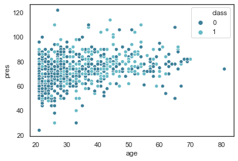

```python
sns.scatterplot(x="age",y="pres",data=clean,hue='class',palette='GnBu_d')
```

As age increase we see an increasing incidence of higher blood pressure.

##### Age Level and Blood Pressure Varied By Disease Classification Status

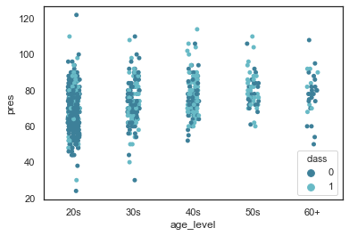

```python
sns.stripplot(x="age_level",y="pres",data=clean,jitter=True,hue='class',palette='GnBu_d')
```

Higher blood pressure measurements predominate the diabetic patient class.

Moreover, we see older age groups experiencing more diabetes and higher blood pressure.

##### Mass and Insulin Varied by Disease Classification Status

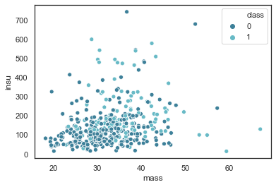

```python
sns.scatterplot(x="mass",y="insu",data=clean,hue='class',palette='GnBu_d')
```

Highest occurence of bmi is associated with higher insulin concentrations.

##### Plasma and Insulin Varied By Disease Classification Status

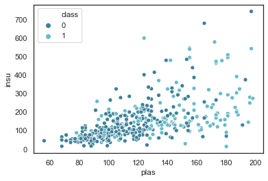

```python
sns.scatterplot(x="plas",y="insu",data=clean,hue='class',palette='GnBu_d')
```

Biologically insulin is a response to store glucose found in the blood plasma. Diabetics are either unresponsive to to insulin due to physiological interactions derived from high fat body mass (T2 diabetes). Alternatively, the patient lost activity of the pancreatic beta islet cells and can no longer produce insulin (T1 diabetes).

In diabetic patiets we see that insulin values begin frequently at 100 and increase as high as 600. Moreover, as plasma values reach 140 and above, we see the patients are predominantly diabetic.

##### Plasma and Insulin Varied By Age Level

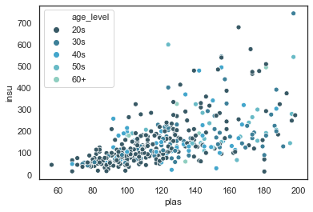

```python
sns.scatterplot(x="plas",y="insu",data=clean,hue='age_level',palette='GnBu_d')
```

All age groups are incorporated into the window of diabetics with plasma concentration 140 and above.

##### Age and Insulin Varied by Class

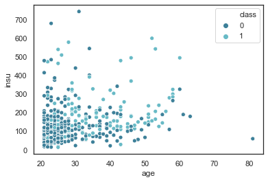

```python
sns.scatterplot(x="age",y="insu",data=clean,hue='class',palette='GnBu_d')
```

As age increase we see a higher occurrence of diabetic individuals with high insulin values.

##### Final Analysis, Cleaning, and Recommendations

There exists an exorbitant amount of NaN values in data variable columns skin and insulin.

Since higher skin thickness is highly correlated with increased mass, there may exist multicollinearity.

Furthermore, insulin is a response to blood glucose plasma, there may exist multicollinearity as well.

Moreover, since age_level is derived from age it will undoubtedly exhibit multicollinearity.

In order to preserve total row count, data integrity, and proceed with SVM, we will take measures to remove insulin, skin and age_level from the dataset.

Final dataset will contain 768 patients over 7 column variables.

```python
clean = clean.drop(['insu'], axis = 1)
clean = clean.drop(['skin'], axis = 1)
clean = clean.drop(['age_level'], axis = 1)
clean.head(7)
clean.isna().sum()
```

```
preg      0
plas      6
pres     35
mass     11
pedi      0
age       0
class     0
dtype: int64
```

```python
clean['plas'].fillna(clean.plas.median(),inplace=True)
clean['pres'].fillna(clean.plas.median(),inplace=True)
clean['mass'].fillna(clean.plas.median(),inplace=True)
```

```python
clean.describe()
```

|  | preg | plas | pres | mass | pedi | age | class |
| --- | --- | --- | --- | --- | --- | --- | --- |
| count | 768.000000 | 768.000000 | 768.000000 | 768.000000 | 768.000000 | 768.000000 | 768.000000 |
| mean | 3.845052 | 121.549479 | 74.437500 | 33.668359 | 0.471876 | 33.240885 | 0.348958 |
| std | 3.369578 | 30.310177 | 15.262202 | 12.178062 | 0.331329 | 11.760232 | 0.476951 |
| min | 0.000000 | 44.000000 | 24.000000 | 18.200000 | 0.078000 | 21.000000 | 0.000000 |
| 25% | 1.000000 | 99.750000 | 64.000000 | 27.500000 | 0.243750 | 24.000000 | 0.000000 |
| 50% | 3.000000 | 117.000000 | 73.000000 | 32.400000 | 0.372500 | 29.000000 | 0.000000 |
| 75% | 6.000000 | 140.000000 | 82.000000 | 36.825000 | 0.626250 | 41.000000 | 1.000000 |
| max | 17.000000 | 198.000000 | 122.000000 | 117.000000 | 2.420000 | 81.000000 | 1.000000 |

```python
clean.info()
```

```
<class 'pandas.core.frame.DataFrame'>
RangeIndex: 768 entries, 0 to 767
Data columns (total 7 columns):
preg     768 non-null int64
plas     768 non-null float64
pres     768 non-null float64
mass     768 non-null float64
pedi     768 non-null float64
age      768 non-null int64
class    768 non-null int64
dtypes: float64(4), int64(3)
memory usage: 42.1 KB
```